# Statistical Inference Course Project part 1

## Question 2

Show how variable the sample is (via variance) and compare it to the theoretical variance of the distribution.

In order to obtain variance, we first calculate the standard deviation of our exponential means distribution from the 1000 simulations:

```r
exp_sim_sd <- sd(exp_sim_means)
```

```
## [1] 0.7749455
```

And now the variance:

```r
exp_sim_var <- exp_sim_sd^2
```

```
## [1] 0.6005405
```

… which the same as:

```r
exp_sim_var <- var(exp_sim_means)
```

```
## [1] 0.6005405
```

Theoretical standard deviation is calculated by the expression

```r
exp_sim_sd_theoretical <- (1/lambda)/sqrt(n)
```

```
## [1] 0.7905694
```

… and theoretical variance is standard deviation squared

```r
exp_sim_var_theoretical <- ((1/lambda)/sqrt(n))^2
```

```
## [1] 0.625
```

Standard deviation of our simulated exponentials is 0.7749455, with the theoretical standard deviation of 0.7905694. Variances obtained from simulations and theoretical calculations (sandard deviation squared) are 0.6005405 and 0.625, respectively. If we used more simulation runs and larger sample sizes, the calculated numbers would be even closer to the theoretical ones (CLT).

## Question 3

Show that the distribution is approximately normal.

scale() function comes in handy when plotting the distribution:

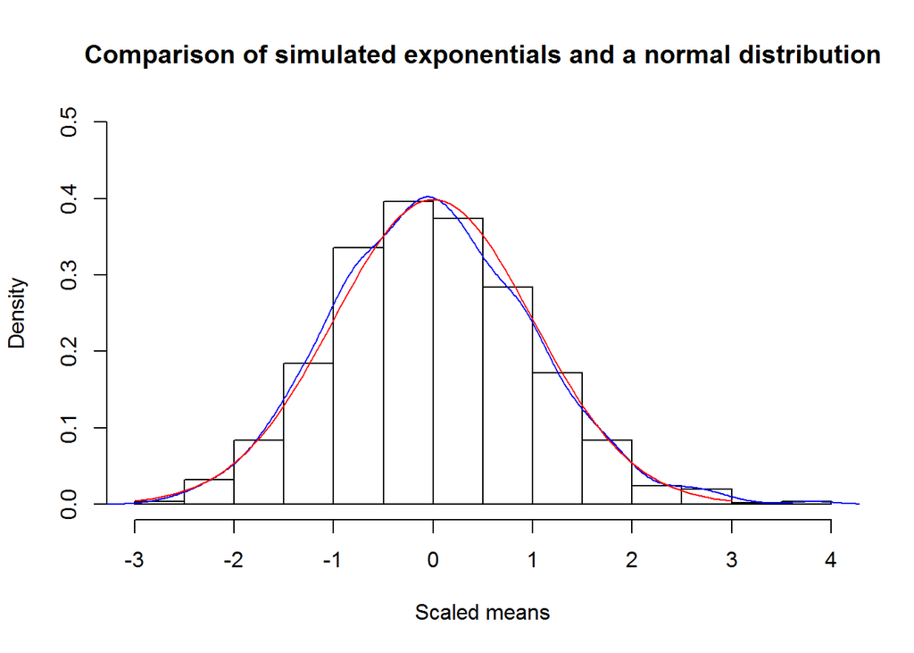

```r
exp_sim_means_scaled <- scale(exp_sim_means)

hist(exp_sim_means_scaled,
     probability=T,
     main="Comparison of simulated exponentials and a normal distribution",
     xlab="Scaled means",
     ylim=c(0, 0.5))
lines(density(exp_sim_means_scaled), col="blue") # distribution of our means

curve(dnorm(x,0,1), -3, 3, col="red", add=T) # normal distribution
```